# Problem Statement

# **Sample Image with Lung Opacity**

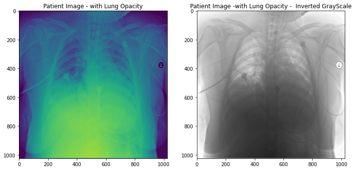

```python
sample_Patient1 = train_df['patientId'][4]
image_path1 = train_images_path %sample_Patient1
image_data1=dcm.read_file(image_path1)
plt.figure(figsize=(12,10))
plt.subplot(121)
plt.imshow(image_data1.pixel_array)
plt.title('Patient Image - with Lung Opacity')
plt.subplot(122)
plt.imshow(image_data1.pixel_array, cmap=plt.cm.gist_gray_r)
plt.title('Patient Image -with Lung Opacity -  Inverted GrayScale')
```

```python
# To extract meta data from image files
# This takes lot of time to execute, hence saved the extracted data into a new CSV and will import that file for further EDA

#age=[]
#gender=[]
#i=1
#for img in train_df['patientId']:
#  pid = img
#  img_dat = '/content/drive/My Drive/Capstone/stage_2_train_images/%s.dcm' %img
#  img_meta = pydicom.read_file(img_dat)
#  ag1 = img_meta.PatientAge
#  gen = img_meta.PatientSex
#  age.append(ag1)
#  gender.append(gen)
#  print("Completed:"+str(i))
#  i=i+1
```

```python
#train_df_copy = pd.read_csv("C:\\Users\\Laurie\\Documents\\Learning\\PG AIML\\16_CAPSTONE\\Project data files\\unzipped\\Data_with_Meta (1).csv")
train_df_copy = pd.read_csv('Data_with_Meta.csv')
```

```python
train_df_copy.head()
```

|  | Unnamed: 0 | patientId | x | y | width | height | Target | class | Age | Gender |
| --- | --- | --- | --- | --- | --- | --- | --- | --- | --- | --- |
| 0 | 0 | 0004cfab-14fd-4e49-80ba-63a80b6bddd6 | NaN | NaN | NaN | NaN | 0 | No Lung Opacity / Not Normal | 51 | F |
| 1 | 1 | 00313ee0-9eaa-42f4-b0ab-c148ed3241cd | NaN | NaN | NaN | NaN | 0 | No Lung Opacity / Not Normal | 48 | F |
| 2 | 2 | 00322d4d-1c29-4943-afc9-b6754be640eb | NaN | NaN | NaN | NaN | 0 | No Lung Opacity / Not Normal | 19 | M |
| 3 | 3 | 003d8fa0-6bf1-40ed-b54c-ac657f8495c5 | NaN | NaN | NaN | NaN | 0 | Normal | 28 | M |
| 4 | 4 | 00436515-870c-4b36-a041-de91049b9ab4 | 264.0 | 152.0 | 213.0 | 379.0 | 1 | Lung Opacity | 32 | F |

```python
train_df_copy.fillna(0)
```

|  | Unnamed: 0 | patientId | x | y | width | height | Target | class | Age | Gender |
| --- | --- | --- | --- | --- | --- | --- | --- | --- | --- | --- |
| 0 | 0 | 0004cfab-14fd-4e49-80ba-63a80b6bddd6 | 0.0 | 0.0 | 0.0 | 0.0 | 0 | No Lung Opacity / Not Normal | 51 | F |
| 1 | 1 | 00313ee0-9eaa-42f4-b0ab-c148ed3241cd | 0.0 | 0.0 | 0.0 | 0.0 | 0 | No Lung Opacity / Not Normal | 48 | F |
| 2 | 2 | 00322d4d-1c29-4943-afc9-b6754be640eb | 0.0 | 0.0 | 0.0 | 0.0 | 0 | No Lung Opacity / Not Normal | 19 | M |
| 3 | 3 | 003d8fa0-6bf1-40ed-b54c-ac657f8495c5 | 0.0 | 0.0 | 0.0 | 0.0 | 0 | Normal | 28 | M |
| 4 | 4 | 00436515-870c-4b36-a041-de91049b9ab4 | 264.0 | 152.0 | 213.0 | 379.0 | 1 | Lung Opacity | 32 | F |
| ... | ... | ... | ... | ... | ... | ... | ... | ... | ... | ... |
| 30222 | 30222 | c1ec14ff-f6d7-4b38-b0cb-fe07041cbdc8 | 185.0 | 298.0 | 228.0 | 379.0 | 1 | Lung Opacity | 54 | M |
| 30223 | 30223 | c1edf42b-5958-47ff-a1e7-4f23d99583ba | 0.0 | 0.0 | 0.0 | 0.0 | 0 | Normal | 46 | F |
| 30224 | 30224 | c1f6b555-2eb1-4231-98f6-50a963976431 | 0.0 | 0.0 | 0.0 | 0.0 | 0 | Normal | 45 | M |
| 30225 | 30225 | c1f7889a-9ea9-4acb-b64c-b737c929599a | 570.0 | 393.0 | 261.0 | 345.0 | 1 | Lung Opacity | 72 | F |
| 30226 | 30226 | c1f7889a-9ea9-4acb-b64c-b737c929599a | 233.0 | 424.0 | 201.0 | 356.0 | 1 | Lung Opacity | 72 | F |

30227 rows × 10 columns

```python
vars = ['Modality', 'PatientAge', 'PatientSex', 'BodyPartExamined', 'ViewPosition', 'ConversionType', 'Rows', 'Columns', 'PixelSpacing']
```

```python
for i, img_name in tqdm(enumerate(vars)):
    print(img_name)
```

```
9it [00:00, 43190.77it/s]
```

```
Modality
PatientAge
PatientSex
BodyPartExamined
ViewPosition
ConversionType
Rows
Columns
PixelSpacing
```

```python
def process_dicom_data(data_df, data_path):
    for var in vars:
        data_df[var] = None
    image_names = os.listdir(PATH+data_path)
    for i, img_name in tqdm(enumerate(image_names)):
        imagePath = os.path.join(PATH,data_path,img_name)
        data_row_img_data = dcm.read_file(imagePath)
        idx = (data_df['patientId']==data_row_img_data.PatientID)
        data_df.loc[idx,'Modality'] = data_row_img_data.Modality
        data_df.loc[idx,'PatientAge'] = pd.to_numeric(data_row_img_data.PatientAge)
        data_df.loc[idx,'PatientSex'] = data_row_img_data.PatientSex
        data_df.loc[idx,'BodyPartExamined'] = data_row_img_data.BodyPartExamined
        data_df.loc[idx,'ViewPosition'] = data_row_img_data.ViewPosition
        data_df.loc[idx,'ConversionType'] = data_row_img_data.ConversionType
        data_df.loc[idx,'Rows'] = data_row_img_data.Rows
        data_df.loc[idx,'Columns'] = data_row_img_data.Columns
        data_df.loc[idx,'PixelSpacing'] = str.format("{:4.3f}",data_row_img_data.PixelSpacing[0])
```

```python
PATH ='rsna-pneumonia-detection-challenge/'
#rsna-pneumonia-detection-df = train_df.copy
process_dicom_data(train_df,'stage_2_train_images/')
```

```
13106it [03:41, 59.11it/s]
```

```python
train_df.head()
```

|  | patientId | x | y | width | height | Target | class | Modality | PatientAge | PatientSex | BodyPartExamined | ViewPosition | ConversionType | Rows | Columns | PixelSpacing |
| --- | --- | --- | --- | --- | --- | --- | --- | --- | --- | --- | --- | --- | --- | --- | --- | --- |
| 0 | 0004cfab-14fd-4e49-80ba-63a80b6bddd6 | NaN | NaN | NaN | NaN | 0 | No Lung Opacity / Not Normal | CR | 51 | F | CHEST | PA | WSD | 1024 | 1024 | 0.143 |
| 1 | 00313ee0-9eaa-42f4-b0ab-c148ed3241cd | NaN | NaN | NaN | NaN | 0 | No Lung Opacity / Not Normal | CR | 48 | F | CHEST | PA | WSD | 1024 | 1024 | 0.194 |
| 2 | 00322d4d-1c29-4943-afc9-b6754be640eb | NaN | NaN | NaN | NaN | 0 | No Lung Opacity / Not Normal | CR | 19 | M | CHEST | AP | WSD | 1024 | 1024 | 0.168 |
| 3 | 003d8fa0-6bf1-40ed-b54c-ac657f8495c5 | NaN | NaN | NaN | NaN | 0 | Normal | CR | 28 | M | CHEST | PA | WSD | 1024 | 1024 | 0.143 |
| 4 | 00436515-870c-4b36-a041-de91049b9ab4 | 264.0 | 152.0 | 213.0 | 379.0 | 1 | Lung Opacity | CR | 32 | F | CHEST | AP | WSD | 1024 | 1024 | 0.139 |

```python
import seaborn as sns
```

```python
train_df_copy.info()
```

```
<class 'pandas.core.frame.DataFrame'>
RangeIndex: 30227 entries, 0 to 30226
Data columns (total 10 columns):
 #   Column      Non-Null Count  Dtype
---  ------      --------------  -----
 0   Unnamed: 0  30227 non-null  int64
 1   patientId   30227 non-null  object
 2   x           9555 non-null   float64
 3   y           9555 non-null   float64
 4   width       9555 non-null   float64
 5   height      9555 non-null   float64
 6   Target      30227 non-null  int64
 7   class       30227 non-null  object
 8   Age         30227 non-null  int64
 9   Gender      30227 non-null  object
dtypes: float64(4), int64(3), object(3)
memory usage: 2.3+ MB
```

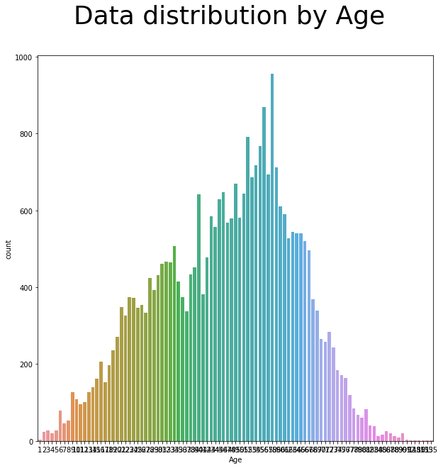

```python
plt.figure(figsize=(10,10))
plt.suptitle("Data distribution by Age", fontsize=36)
sns.countplot(train_df_copy['Age'])
```

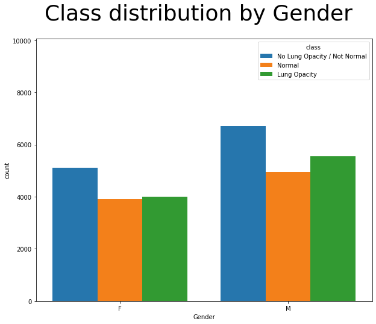

```python
plt.figure(figsize=(10,8))
plt.margins(0.5, tight= False)
plt.suptitle("Class distribution by Gender", fontsize=36)

sns.countplot(x="Gender", hue="class", data=train_df_copy, saturation=0.9)
```

```python
data_lung_opacity = train_df_copy[train_df_copy['class'] == "Lung Opacity"]
```

```python
data_lung_opacity.head()
```

|  | Unnamed: 0 | patientId | x | y | width | height | Target | class | Age | Gender |
| --- | --- | --- | --- | --- | --- | --- | --- | --- | --- | --- |
| 4 | 4 | 00436515-870c-4b36-a041-de91049b9ab4 | 264.0 | 152.0 | 213.0 | 379.0 | 1 | Lung Opacity | 32 | F |
| 5 | 5 | 00436515-870c-4b36-a041-de91049b9ab4 | 562.0 | 152.0 | 256.0 | 453.0 | 1 | Lung Opacity | 32 | F |
| 8 | 8 | 00704310-78a8-4b38-8475-49f4573b2dbb | 323.0 | 577.0 | 160.0 | 104.0 | 1 | Lung Opacity | 75 | M |
| 9 | 9 | 00704310-78a8-4b38-8475-49f4573b2dbb | 695.0 | 575.0 | 162.0 | 137.0 | 1 | Lung Opacity | 75 | M |
| 14 | 14 | 00aecb01-a116-45a2-956c-08d2fa55433f | 288.0 | 322.0 | 94.0 | 135.0 | 1 | Lung Opacity | 6 | F |

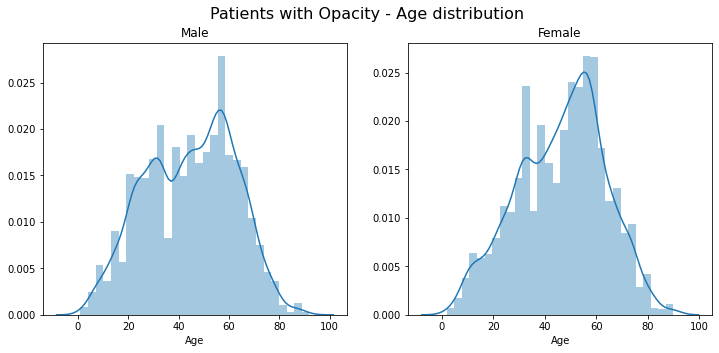

```python
plt.figure(figsize=(12,5))
plt.suptitle('Patients with Opacity - Age distribution', fontsize=16)
plt.subplot(121)
male = data_lung_opacity[data_lung_opacity['Gender']=="M"]
sns.distplot(male['Age'])
plt.title('Male')
plt.subplot(122)
Female = data_lung_opacity[data_lung_opacity['Gender']=="F"]
sns.distplot(Female['Age'])
plt.title('Female')
```

# EDA Notes

## **Files provided**

1. Detailed Class File that contains Patient ID and Classification if the patient has Lung Opacity, Normal or Not normal condution

   ```
    a.This file has 30227 entries
   ```

2. Train Labels File that has Patient ID, pixel co-ordinates that serve as bounding box for patients that suffer lung opacity issue and the same is confirmed by last column ie Target

   ```
    a. The target column has two value 0 for patients with no lung opacity issues and 1 for patients with lung opacity issues
    b. This file too has 30227 entries
   ```

## **Dataframe Processing**

Data in both files mentioned above were consolidated to create a new Pandas DataFrame called train_df train_df now has 30227 entries with 7 columns

## **Observations from EDA**

From the graphs and Value Counts it is evident to note that there is class imbalance

```
No Lung Opacity / Not Normal    11821
Lung Opacity                     9555
Normal                           8851
```

If we consider Normal and No Lung Opacity as one class, then the class distribution is as follows:

```
No Lung Opacity       20672
With Lung Opacity     9555
```

Of the total 30227 records we have :

```
26684 unique patient records
3543 records are duplicated
all duplicated records belong to class - Patient with Lung Opacity
Data types : float64(4), int64(1), object(2)
```

## **Observations from Sample Image**

```
All images are in DCM format, had to install pydicom to read the images
All images come with Metadata
All images are of resolution 1024 X 1024
pydicom library provides the pixel array
```

## Gender distribution for positive lung opacity

1. Higher number of males reported for lung opacity
2. Lung opacity is seen to be more frequent in patients of age group between 50 years to 70 years

# Dealing with Class imbalance

There are 2 approaches being explored :

## Approach 1 : Downsample

```python
train_df_copy.shape
```

```
(30227, 10)
```

```python
count_class_0, count_class_1 = train_df_copy.Target.value_counts()
print(count_class_0)
print(count_class_1)
```

```
20672
9555
```

```python
# Divide by class
df_class_0 = train_df_copy[train_df_copy['Target'] == 0]
df_class_1 = train_df_copy[train_df_copy['Target'] == 1]
```

```python
new_class0 = df_class_0.sample(count_class_1)
```

```python
downsampled_df  = pd.concat([new_class0[:1000],df_class_1[:1000]], axis=0)
```

```python
print(downsampled_df.Target.value_counts())
```

```
1    1000
0    1000
Name: Target, dtype: int64
```

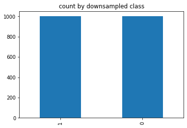

```python
downsampled_df.Target.value_counts().plot(kind='bar', title = "count by downsampled class")
```

## Approach 2 : Upsample

```python
new_class1 = df_class_1.sample(count_class_0, replace= True)
```

```python
upsampled_df  = pd.concat([new_class1,df_class_0], axis=0)
```

```python
print(upsampled_df.Target.value_counts())
```

```
1    20672
0    20672
Name: Target, dtype: int64
```

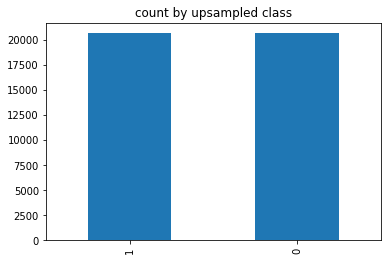

```python
upsampled_df.Target.value_counts().plot(kind='bar', title = "count by upsampled class")
```

# Approach:

The following models are being explored in the project to assess which model delivers better accuracy

```python
import tensorflow
print(tensorflow.__version__)
import pandas as pd
import pylab
import matplotlib.pyplot as plt
from os.path import dirname, join
from pprint import pprint

import pydicom
from pydicom.data import get_testdata_file
from pydicom.filereader import read_dicomdir


import pandas as pd
import numpy as np
import matplotlib
import matplotlib.pyplot as plt
from tqdm import tqdm_notebook
#from tqdm.notebook import tqdm
from matplotlib.patches import Rectangle
import seaborn as sns
import pydicom as dcm
%matplotlib inline
import os
from tensorflow.keras.applications.resnet50 import ResNet50
from tensorflow.keras.preprocessing import image
from tensorflow.keras.applications.resnet50 import preprocess_input, decode_predictions
import numpy as np
```

```
1.14.0
```

```python
downsampled_df.shape
```

```
(2000, 10)
```

```python
X = downsampled_df['patientId']
y = downsampled_df['Target']
```

```python
from glob import glob
import os
base = "rsna-pneumonia-detection-challenge/stage_2_train_images"

dicom_files = os.listdir(base)
```

```python
downsampled_df=downsampled_df.fillna(0)
downsampled_df.reset_index()
```

|  | index | Unnamed: 0 | patientId | x | y | width | height | Target | class | Age | Gender |
| --- | --- | --- | --- | --- | --- | --- | --- | --- | --- | --- | --- |
| 0 | 6764 | 6764 | 5173dd85-b9c2-42e6-8a44-37b82efd1f83 | 0.0 | 0.0 | 0.0 | 0.0 | 0 | No Lung Opacity / Not Normal | 61 | F |
| 1 | 4003 | 4003 | 3c1410ec-5f53-4538-b6e3-fcd1bae93be6 | 0.0 | 0.0 | 0.0 | 0.0 | 0 | Normal | 47 | M |
| 2 | 26159 | 26159 | e9b7cd5d-3d54-48d4-a784-8abae7369366 | 0.0 | 0.0 | 0.0 | 0.0 | 0 | Normal | 31 | M |
| 3 | 1640 | 1640 | 17af0269-b24a-462b-bb27-01ca17cb6494 | 0.0 | 0.0 | 0.0 | 0.0 | 0 | No Lung Opacity / Not Normal | 75 | M |
| 4 | 17675 | 17675 | a885cd60-df31-42da-bf0d-6a422db89a76 | 0.0 | 0.0 | 0.0 | 0.0 | 0 | Normal | 22 | M |
| ... | ... | ... | ... | ... | ... | ... | ... | ... | ... | ... | ... |
| 1995 | 2311 | 2311 | 30d3d2f9-4342-4ab4-9032-34d894c2cfbb | 673.0 | 522.0 | 73.0 | 86.0 | 1 | Lung Opacity | 84 | M |
| 1996 | 2312 | 2312 | 30d3d2f9-4342-4ab4-9032-34d894c2cfbb | 256.0 | 546.0 | 98.0 | 87.0 | 1 | Lung Opacity | 84 | M |
| 1997 | 2313 | 2313 | 30d3d2f9-4342-4ab4-9032-34d894c2cfbb | 317.0 | 327.0 | 119.0 | 143.0 | 1 | Lung Opacity | 84 | M |
| 1998 | 2315 | 2315 | 31102758-a5ba-44c9-b480-b744bcfcb861 | 526.0 | 699.0 | 147.0 | 198.0 | 1 | Lung Opacity | 66 | F |
| 1999 | 2316 | 2316 | 31102758-a5ba-44c9-b480-b744bcfcb861 | 208.0 | 262.0 | 119.0 | 103.0 | 1 | Lung Opacity | 66 | F |

2000 rows × 11 columns

```python
Taining_file_df = pd.DataFrame(columns=['patientId'],data=dicom_files)
Taining_file_df["patientId"]= Taining_file_df["patientId"].str.replace(".dcm", "")
Taining_file_df["patientId"][0]
```

```
'0004cfab-14fd-4e49-80ba-63a80b6bddd6'
```

```python
downsampled_df.loc[downsampled_df['patientId'] == Taining_file_df["patientId"][100]][:1]
```

|  | Unnamed: 0 | patientId | x | y | width | height | Target | class | Age | Gender |
| --- | --- | --- | --- | --- | --- | --- | --- | --- | --- | --- |
| 76 | 76 | 01f3abc2-33c7-4ea2-a599-dc49b76fcfae | 676.0 | 292.0 | 163.0 | 186.0 | 1 | Lung Opacity | 51 | F |

```python
#import h5py
#import numpy as np
final_taining_df = pd.merge(Taining_file_df, downsampled_df, on='patientId')
```

```python
print("Down sampling : " ,len(downsampled_df))
print("Avalable traning images : " ,len(Taining_file_df))
print("Traning images : " ,len(final_taining_df))
```

```
Down sampling :  2000
Avalable traning images :  13106
Traning images :  1473
```

```python
final_taining_df.reset_index()
```

|  | index | patientId | Unnamed: 0 | x | y | width | height | Target | class | Age | Gender |
| --- | --- | --- | --- | --- | --- | --- | --- | --- | --- | --- | --- |
| 0 | 0 | 0010f549-b242-4e94-87a8-57d79de215fc | 28996 | 0.0 | 0.0 | 0.0 | 0.0 | 0 | Normal | 56 | M |
| 1 | 1 | 00436515-870c-4b36-a041-de91049b9ab4 | 4 | 264.0 | 152.0 | 213.0 | 379.0 | 1 | Lung Opacity | 32 | F |
| 2 | 2 | 00436515-870c-4b36-a041-de91049b9ab4 | 5 | 562.0 | 152.0 | 256.0 | 453.0 | 1 | Lung Opacity | 32 | F |
| 3 | 3 | 0053ee32-1e03-4dc2-a103-f46ad0448787 | 29007 | 0.0 | 0.0 | 0.0 | 0.0 | 0 | Normal | 56 | M |
| 4 | 4 | 006e75c8-1fd9-4a5a-99e7-285addebed55 | 29010 | 0.0 | 0.0 | 0.0 | 0.0 | 0 | No Lung Opacity / Not Normal | 63 | F |
| ... | ... | ... | ... | ... | ... | ... | ... | ... | ... | ... | ... |
| 1468 | 1468 | 882e6633-37ae-4100-a315-5de37a6a1cca | 13566 | 0.0 | 0.0 | 0.0 | 0.0 | 0 | Normal | 54 | F |
| 1469 | 1469 | 887f9d66-dc43-4b65-ad31-61f935b9effc | 13609 | 0.0 | 0.0 | 0.0 | 0.0 | 0 | No Lung Opacity / Not Normal | 64 | M |
| 1470 | 1470 | 88ff2af0-a757-4bc4-b04b-031619dac4e3 | 13668 | 0.0 | 0.0 | 0.0 | 0.0 | 0 | No Lung Opacity / Not Normal | 37 | M |
| 1471 | 1471 | 89092a09-18b7-450b-a7b0-58cd6c147919 | 13671 | 0.0 | 0.0 | 0.0 | 0.0 | 0 | Normal | 53 | M |
| 1472 | 1472 | 8949f382-c28f-462b-a902-058818235e3b | 13706 | 0.0 | 0.0 | 0.0 | 0.0 | 0 | Normal | 48 | F |

1473 rows × 11 columns

# Implementing U-NET through transfer learning

```python
!pip install segmentation-models
```

```python
#Import libraries
from segmentation_models import Unet
#from segmentation_models.backbones import get_preprocessing
from segmentation_models.losses import bce_jaccard_loss
from segmentation_models.metrics import iou_score
from segmentation_models.utils import set_trainable
from keras.layers import Input, Conv2D
from keras.models import Model
```

```
Segmentation Models: using `keras` framework.
```

```python
Taining_file_df.head()
```

|  | patientId |
| --- | --- |
| 0 | 0004cfab-14fd-4e49-80ba-63a80b6bddd6 |
| 1 | 000924cf-0f8d-42bd-9158-1af53881a557 |
| 2 | 000db696-cf54-4385-b10b-6b16fbb3f985 |
| 3 | 000fe35a-2649-43d4-b027-e67796d412e0 |
| 4 | 001031d9-f904-4a23-b3e5-2c088acd19c6 |

```python
#testData = final_taining_df
#testData = train_df_copy[0:1000]
testData = train_df_copy
testData = testData.fillna(0)
testData = testData.reset_index()
```

```python
from skimage.io import imread, imshow, concatenate_images
from skimage.transform import resize
import os.path
from tqdm import tqdm
IMAGE_HEIGHT, IMAGE_WIDTH = 224,224
ORG_HEIGHT, ORG_WIDTH =1024,1024
import cv2
from tensorflow.keras.applications.mobilenet import preprocess_input
```

```python
from tqdm import tqdm
IMAGE_HEIGHT, IMAGE_WIDTH = 224,224
ORG_HEIGHT, ORG_WIDTH =1024,1024
import cv2
from tensorflow.keras.applications.mobilenet import preprocess_input
train_masks = np.zeros((int(final_taining_df.shape[0]), IMAGE_HEIGHT, IMAGE_WIDTH,3), dtype=np.uint8)
train_images = np.zeros((int(final_taining_df.shape[0]), IMAGE_HEIGHT, IMAGE_WIDTH, 3), dtype=np.uint8)
for index in tqdm(range(final_taining_df.shape[0])):
          image_id = final_taining_df["patientId"][index]
          fname = str(image_id)
          image_path = train_images_path %fname
          info2 = pydicom.read_file(image_path)
          image = info2.pixel_array
          if len(image.shape) != 3 or image.shape[2] != 3:
              image = np.stack((image,) * 3, -1)
              img = cv2.resize(image, dsize=(IMAGE_HEIGHT, IMAGE_WIDTH), interpolation=cv2.INTER_CUBIC)
              train_images[index]= img
          Target = final_taining_df["Target"][index]
          if Target == 1:
              x = int(final_taining_df['x'][index])
              y = int(final_taining_df['y'][index])
              w = int(final_taining_df['width'][index])
              h = int(final_taining_df['height'][index])
              x1 = int(int(x * IMAGE_WIDTH)/ORG_WIDTH)
              x2 = int(int((x+w) * IMAGE_WIDTH)/ORG_WIDTH)
              y1 = int(int(y * IMAGE_HEIGHT)/ORG_HEIGHT)
              y2 = int(int((y+h) * IMAGE_HEIGHT)/ORG_HEIGHT)
              mask_img=np.zeros((IMAGE_HEIGHT, IMAGE_WIDTH,3),np.uint8)
              img_mod= cv2.rectangle(mask_img,(x1,x2),(x2,y2),(255,0,0),3)
              train_masks[index] = img_mod
```

```python
from sklearn.model_selection import train_test_split
X_train, X_test, y_train, y_test = train_test_split(train_images,train_masks, test_size=0.30, random_state=42)
```

```python
print(X_train.shape)
print(X_test.shape)
```

```
(1031, 224, 224, 3)
(442, 224, 224, 3)
```

```python
print(y_train.shape)
print(y_test.shape)
```

```
(1031, 224, 224, 3)
(442, 224, 224, 3)
```

```python
train_datagen = (X_train,y_train)
validation_datagen = (X_test,y_test)
```

```python
print(train_images.shape)
print(train_masks.shape)
```

```
(1473, 224, 224, 3)
(1473, 224, 224, 3)
```

```python
final_taining_df.head(20)
```

|  | patientId | Unnamed: 0 | x | y | width | height | Target | class | Age | Gender |
| --- | --- | --- | --- | --- | --- | --- | --- | --- | --- | --- |
| 0 | 0010f549-b242-4e94-87a8-57d79de215fc | 28996 | 0.0 | 0.0 | 0.0 | 0.0 | 0 | Normal | 56 | M |
| 1 | 00436515-870c-4b36-a041-de91049b9ab4 | 4 | 264.0 | 152.0 | 213.0 | 379.0 | 1 | Lung Opacity | 32 | F |
| 2 | 00436515-870c-4b36-a041-de91049b9ab4 | 5 | 562.0 | 152.0 | 256.0 | 453.0 | 1 | Lung Opacity | 32 | F |
| 3 | 0053ee32-1e03-4dc2-a103-f46ad0448787 | 29007 | 0.0 | 0.0 | 0.0 | 0.0 | 0 | Normal | 56 | M |
| 4 | 006e75c8-1fd9-4a5a-99e7-285addebed55 | 29010 | 0.0 | 0.0 | 0.0 | 0.0 | 0 | No Lung Opacity / Not Normal | 63 | F |
| 5 | 00704310-78a8-4b38-8475-49f4573b2dbb | 8 | 323.0 | 577.0 | 160.0 | 104.0 | 1 | Lung Opacity | 75 | M |
| 6 | 00704310-78a8-4b38-8475-49f4573b2dbb | 9 | 695.0 | 575.0 | 162.0 | 137.0 | 1 | Lung Opacity | 75 | M |
| 7 | 00aecb01-a116-45a2-956c-08d2fa55433f | 14 | 288.0 | 322.0 | 94.0 | 135.0 | 1 | Lung Opacity | 6 | F |
| 8 | 00aecb01-a116-45a2-956c-08d2fa55433f | 15 | 547.0 | 299.0 | 119.0 | 165.0 | 1 | Lung Opacity | 6 | F |
| 9 | 00c0b293-48e7-4e16-ac76-9269ba535a62 | 16 | 306.0 | 544.0 | 168.0 | 244.0 | 1 | Lung Opacity | 23 | F |
| 10 | 00c0b293-48e7-4e16-ac76-9269ba535a62 | 17 | 650.0 | 511.0 | 206.0 | 284.0 | 1 | Lung Opacity | 23 | F |
| 11 | 00f08de1-517e-4652-a04f-d1dc9ee48593 | 19 | 181.0 | 184.0 | 206.0 | 506.0 | 1 | Lung Opacity | 58 | M |
| 12 | 00f08de1-517e-4652-a04f-d1dc9ee48593 | 20 | 571.0 | 275.0 | 230.0 | 476.0 | 1 | Lung Opacity | 58 | M |
| 13 | 0100515c-5204-4f31-98e0-f35e4b00004a | 22 | 703.0 | 416.0 | 84.0 | 77.0 | 1 | Lung Opacity | 28 | F |
| 14 | 010ccb9f-6d46-4380-af11-84f87397a1b8 | 24 | 652.0 | 437.0 | 161.0 | 293.0 | 1 | Lung Opacity | 21 | M |
| 15 | 010ccb9f-6d46-4380-af11-84f87397a1b8 | 25 | 301.0 | 405.0 | 141.0 | 279.0 | 1 | Lung Opacity | 21 | M |
| 16 | 012a5620-d082-4bb8-9b3b-e72d8938000c | 27 | 133.0 | 613.0 | 275.0 | 275.0 | 1 | Lung Opacity | 60 | M |
| 17 | 012a5620-d082-4bb8-9b3b-e72d8938000c | 28 | 678.0 | 427.0 | 224.0 | 340.0 | 1 | Lung Opacity | 60 | M |
| 18 | 0174c4bb-28f5-41e3-a13f-a396badc18bd | 32 | 155.0 | 182.0 | 273.0 | 501.0 | 1 | Lung Opacity | 23 | M |
| 19 | 0174c4bb-28f5-41e3-a13f-a396badc18bd | 33 | 599.0 | 220.0 | 227.0 | 508.0 | 1 | Lung Opacity | 23 | M |

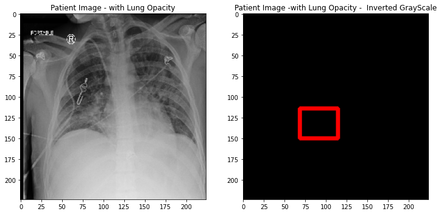

```python
plt.figure(figsize=(12,10))
plt.subplot(121)
plt.imshow(X_train[4], cmap=plt.cm.gist_gray_r)
plt.title('Patient Image - with Lung Opacity')
plt.subplot(122)
plt.imshow(y_train[4], cmap=plt.cm.gist_gray_r)
plt.title('Patient Image -with Lung Opacity -  Inverted GrayScale')
```

```python
def display_img(sample_image,pred_mask):
    fig, ax = plt.subplots(1, 1)
    ax.imshow(sample_image, alpha=1)
    ax.imshow(pred_mask, alpha=0.5)
    ax.set_axis_off()
    return ax
```

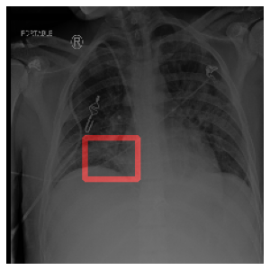

```python
display_img(X_train[4],c)
plt.tight_layout(pad=0.1)
```

```python
import tensorflow as tf
import keras
from keras.optimizers import Adam
from tensorflow.keras.losses import binary_crossentropy
```

```python
def dice_coefficient(y_true, y_pred):
    numerator = 2 * tf.reduce_sum(y_true * y_pred)
    denominator = tf.reduce_sum(y_true + y_pred)

    return numerator / (denominator + tf.keras.backend.epsilon())
```

```python
def loss(y_true, y_pred):
    return binary_crossentropy(y_true, y_pred) - tf.math.log(dice_coefficient(y_true, y_pred) + tf.keras.backend.epsilon())
```

```python
x = X_train[0:50]
y = y_train[0:50]
```

```python
len(x)
```

```
50
```

```python
base_model = Unet(backbone_name='inceptionv3', encoder_weights='imagenet')
base_model.compile('Adam', loss=loss, metrics=[binary_crossentropy])
# pretrain model decoder
#base_model.fit(x, y, epochs=1)
# release all layers for training
#set_trainable(base_model) # set all layers trainable and recompile model

inp = Input(shape=(224, 224, 3))
l1 = Conv2D(3, (1, 1))(inp) # map N channels data to 3 channels
out = base_model(l1)
l2 = Conv2D(3, (1, 1))(out)
model = Model(inp, l2, name=base_model.name)
model.summary()
```

[output not shown]

```python
base_model.summary()
```

[output not shown]

[output cut: 695 more lines]

```
__________________________________________________________________________________________________
decoder_stage4b_conv (Conv2D)   (None, None, None, 1 2304        decoder_stage4a_relu[0][0]
__________________________________________________________________________________________________
decoder_stage4b_bn (BatchNormal (None, None, None, 1 64          decoder_stage4b_conv[0][0]
__________________________________________________________________________________________________
decoder_stage4b_relu (Activatio (None, None, None, 1 0           decoder_stage4b_bn[0][0]
__________________________________________________________________________________________________
final_conv (Conv2D)             (None, None, None, 1 145         decoder_stage4b_relu[0][0]
__________________________________________________________________________________________________
sigmoid (Activation)            (None, None, None, 1 0           final_conv[0][0]
==================================================================================================
Total params: 29,933,105
Trainable params: 29,896,689
Non-trainable params: 36,416
__________________________________________________________________________________________________
```